# Notebook

## 40_eda_earthquakes.ipynb

**This script provides an EDA and some visualisation for the selected and seismically enriched earthquakes dataset.** The main parts of the routines were developed in previous courses at the University of London by the same author (Mohr, 2021, 2023, 2024a) and have been further refined to meet the needs of this MSc thesis project/research. However, the code has been updated to comply with the latest requirements and package interdependencies. Some comments will be included in this Jupyter Notebook, and the code contains several inline comments. For details on the project/research itself, refer to the appropriate document.

#### References (for this script)

*Mohr, S. (2021) Regional Spatial Clusters of Earthquakes at the Pacific Ring of Fire: Analysing Data from the USGS ANSS ComCat and Building Regional Spatial Clusters. DSM020, Python, examined coursework cw1. University of London.*

*Mohr, S. (2023) Clustering of Earthquakes on a Worldwide Scale with the Help of Big Data Machine Learning Methods. DSM010, Big Data, examined coursework cw2. University of London.*

*Mohr, S. (2024a) Comparing Different Tectonic Setups Considering Publicly Available Basic Earthquake’s Data. DSM050, Data Visualisation, examined coursework cw1. University of London.*

#### History

```
250104 Generation from previous courseworks at the UoL, setup basic logging, add histogram of magnitude,
       add map of earthquakes, check docstrings, add a correlation heatmap, add figures for depth and year
250105 Show logscale for Magnitude histogram
250105 Move shared procedures to shared_procedures.py
250110 Adjust figures to enlarged study area, improve column listings
250120 Switching to parameters.py, adding selectable cluster directory, changing all directories, saving all
       relevant figures to data_dir_cluster
```

#### Todo

```
./.
```

## Preparing the environment

### System information

```python
# which python installation and version are we using here?
print('\n******* Python Info ***********')
!which python
!python --version

# show some CPU and RAM info
print('\n******* CPU Info ***********')
!lscpu
print('\n******* RAM Info (in GB) ***********')
!free -g
```

```
******* Python Info ***********
/bin/python
Python 3.8.10

******* CPU Info ***********
Architecture:                       x86_64
CPU op-mode(s):                     32-bit, 64-bit
Byte Order:                         Little Endian
Address sizes:                      46 bits physical, 48 bits virtual
CPU(s):                             64
On-line CPU(s) list:                0-63
Thread(s) per core:                 2
Core(s) per socket:                 8
Socket(s):                          4
NUMA node(s):                       4
Vendor ID:                          GenuineIntel
CPU family:                         6
Model:                              85
Model name:                         Intel(R) Xeon(R) Gold 6234 CPU @ 3.30GHz
Stepping:                           7
CPU MHz:                            1200.037
CPU max MHz:                        4000.0000
CPU min MHz:                        1200.0000
BogoMIPS:                           6600.00
Virtualization:                     VT-x
L1d cache:                          1 MiB
L1i cache:                          1 MiB
L2 cache:                           32 MiB
L3 cache:                           99 MiB
NUMA node0 CPU(s):                  0,4,8,12,16,20,24,28,32,36,40,44,48,52,56,60
NUMA node1 CPU(s):                  1,5,9,13,17,21,25,29,33,37,41,45,49,53,57,61
NUMA node2 CPU(s):                  2,6,10,14,18,22,26,30,34,38,42,46,50,54,58,6
                                    2
NUMA node3 CPU(s):                  3,7,11,15,19,23,27,31,35,39,43,47,51,55,59,6
                                    3
Vulnerability Gather data sampling: Mitigation; Microcode
Vulnerability Itlb multihit:        KVM: Mitigation: Split huge pages
Vulnerability L1tf:                 Not affected
Vulnerability Mds:                  Not affected
Vulnerability Meltdown:             Not affected
```

[output cut: 24 more lines]

[output not shown]

```python
# show installed packages and versions
!pip freeze
```

[output not shown]

[output cut: 198 more lines]

[output not shown]

### Setting PATH correctly

```python
# there is somewhere a PATH-error on LENA for a while
# adding my packages path to the PATH environment

import sys
sys.path.append("/home/smohr001/.local/lib/python3.8/site-packages")
sys.path
```

```
['/home/smohr001/thesis',
 '/usr/lib/python38.zip',
 '/usr/lib/python3.8',
 '/usr/lib/python3.8/lib-dynload',
 '',
 '/opt/jupyterhub/lib/python3.8/site-packages',
 '/opt/jupyterhub/lib/python3.8/site-packages/IPython/extensions',
 '/home/smohr001/.ipython',
 '/home/smohr001/.local/lib/python3.8/site-packages']
```

### Loading libraries

```python
# importing standard libraries
import sys
import os
import warnings
import datetime
import time
import math
import numpy as np
import pandas as pd
import matplotlib.pyplot as plt
import seaborn as sns
import random
import logging
from IPython.display import display, Javascript

# importing shared procedures for this procect (needs to be a simple .py file)
%run shared_procedures.py

# importing additional libraries
import geopandas as gpd
from shapely.geometry import Point
from shapely import wkt
from tabulate import tabulate
from matplotlib.lines import Line2D
from matplotlib.patches import Rectangle
import matplotlib.gridspec as gridspec
from matplotlib.ticker import LogLocator

# get info about installed and used versions of some important (deep learning) libraries
print("Some important installed libraries:\n")
print(f"Pandas version: {pd.__version__}")
print(f"Numpy version: {np.__version__}")
print(f"Seaborn version: {sns.__version__}")
```

```
Some important installed libraries:

Pandas version: 1.4.1
Numpy version: 1.22.2
Seaborn version: 0.13.2
```

### Setting the script environment

```python
# import the parameters (foreced to reload)
import parameters
import importlib
importlib.reload(parameters)

# print all loaded parameters from the Python file
print("Loaded Parameters:\n")
for key in dir(parameters):
    if not key.startswith("__"):
        value = getattr(parameters, key)
        print(f"parameters.{key} = {value}")
```

```
Loaded Parameters:

parameters.buffer_size_km = 1000
parameters.data_dir = data/scope/gvp_1000
parameters.data_dir_raw = data
parameters.data_ts_dir = data/scope/gvp_1000
parameters.scope_id = gvp_1000
```

```python
# show all matplotlib graphs inline
%matplotlib inline

# setting format to JPG for easy copy & paste for figures
# for high quality outputs choose 'svg'
%config InlineBackend.figure_format = 'jpg'

# adjust display settings to show 20 rows as a standard
pd.set_option('display.max_rows', 20)

# disable warnings (activate after developing the complete code)
warnings.filterwarnings('ignore')

# set script (ipynb notebook) name (e.g. for logging)
script_name = "40_eda_earthquakes.ipynb"

# start parameterized logging
setup_logging(logfile_dir = "log",
              logfile_name = "40_eda.log",
              log_level = logging.INFO,
              script_name = script_name
             )

# set data directory
if(parameters.data_dir_raw):
    data_dir_raw = parameters.data_dir_raw
else:
    data_dir_raw = "data"
logging.info(f"{script_name}: Set raw data directory to './{data_dir_raw}'.")

if(parameters.data_dir):
    data_dir = parameters.data_dir
else:
    data_dir = "data"
logging.info(f"{script_name}: Set scope data directory to './{data_dir}'.")

if(parameters.data_ts_dir):
    data_ts_dir = parameters.data_ts_dir
else:
    data_ts_dir = "data/timeseries"
logging.info(f"{script_name}: Set scope timeseries data directory to './{data_ts_dir}'.")
```

```
2025-01-22 22:15:04,084 - INFO - Starting script '40_eda_earthquakes.ipynb'.
2025-01-22 22:15:04,120 - INFO - Set loglevel to INFO.
2025-01-22 22:15:04,121 - INFO - 40_eda_earthquakes.ipynb: Set raw data directory to './data'.
2025-01-22 22:15:04,122 - INFO - 40_eda_earthquakes.ipynb: Set scope data directory to './data/scope/gvp_1000'.
2025-01-22 22:15:04,123 - INFO - 40_eda_earthquakes.ipynb: Set scope timeseries data directory to './data/scope/gvp_1000'.
```

```python
# set fixed seed for reproducibility
reset_random_seeds(script_name=script_name)
```

```
2025-01-22 22:15:04,130 - INFO - 40_eda_earthquakes.ipynb: Seeding random generators with seed=654321.
```

## Loading data

```python
def list_subdirectories(directory, prefix="cluster_"):
    # Filter subdirectories with the given prefix
    return [name for name in os.listdir(directory) if os.path.isdir(os.path.join(directory, name)) and name.startswith(prefix)]

def choose_subdirectory(directory):
    subdirs = list_subdirectories(directory)

    if not subdirs:
        print(f"No subdirectories starting with 'cluster_' were found in {directory}.")
        return None

    # Print the list of subdirectories with indices
    print("Available subdirectories:")
    for i, subdir in enumerate(subdirs):
        print(f"{i + 1}: {subdir}")

    # Prompt the user to select a subdirectory
    while True:
        try:
            choice = int(input("Enter the number of the subdirectory you want to choose: "))
            if 1 <= choice <= len(subdirs):
                return subdirs[choice - 1]
            else:
                print("Invalid choice. Please enter a number from the list.")
        except ValueError:
            print("Invalid input. Please enter a number.")

# set individual clusterdir for saving
selected_subdir = choose_subdirectory(data_dir)
data_dir_cluster = os.path.join(data_dir, selected_subdir)
data_ts_dir_cluster = os.path.join(data_ts_dir, selected_subdir)
logging.info(f"{script_name}: Set cluster data directory to './{data_dir_cluster}'.")
logging.info(f"{script_name}: Set cluster timeseries data directory to './{data_ts_dir_cluster}'.")

# load dataset
earthquakes_enriched = load_dataset(data_file="earthquakes_enriched.csv", data_dir=data_dir_cluster)
```

```
Available subdirectories:
1: cluster_north_america
2: cluster_sunda_banda
3: cluster_south_america
4: cluster_western_pacific
5: cluster_southwest_pacific
6: cluster_tonga_kermadec
7: cluster_northwest_pacific
8: cluster_middle_america_caribbean
Enter the number of the subdirectory you want to choose: 1
```

```
2025-01-22 22:15:05,401 - INFO - 40_eda_earthquakes.ipynb: Set cluster data directory to './data/scope/gvp_1000/cluster_north_america'.
2025-01-22 22:15:05,403 - INFO - 40_eda_earthquakes.ipynb: Set cluster timeseries data directory to './data/scope/gvp_1000/cluster_north_america'.
2025-01-22 22:15:05,431 - INFO - load_dataset: Data loaded successfully from 'data/scope/gvp_1000/cluster_north_america/earthquakes_enriched.csv'.
```

## Statistics and information

```python
# infos of the dataset
pd.set_option('display.max_rows', None)
print("\nShape:\n" + str(earthquakes_enriched.shape))
print("\nColumns and DataTypes:\n" + str(earthquakes_enriched.dtypes))
pd.set_option('display.max_rows', 20)
display(earthquakes_enriched)
logging.info(f"{script_name}: Used dataset is 'earthquakes_enriched' with {earthquakes_enriched.shape}.")
```

```
Shape:
(2948, 23)

Columns and DataTypes:
datetime       object
Unnamed: 0      int64
id             object
geo_x         float64
geo_y         float64
timeymd        object
year            int64
energy        float64
lon           float64
lat           float64
depth         float64
mag           float64
time            int64
felt          float64
cdi           float64
mmi           float64
alert          object
status         object
tsunami         int64
nst             int64
net            object
sig           float64
geometry       object
dtype: object
```

|  | datetime | Unnamed: 0 | id | geo_x | geo_y | timeymd | year | energy | lon | lat | ... | felt | cdi | mmi | alert | status | tsunami | nst | net | sig | geometry |
| --- | --- | --- | --- | --- | --- | --- | --- | --- | --- | --- | --- | --- | --- | --- | --- | --- | --- | --- | --- | --- | --- |
| 0 | 1970-01-16 | 19 | iscgem800129 | 207.2660 | 60.2500 | 1970-01-16 | 1970 | 1.698244e+13 | -152.7340 | 60.2500 | ... | NaN | NaN | NaN | NaN | reviewed | 0 | 486 | iscgem | NaN | POINT (-152.734 60.25) |
| 1 | 1970-01-22 | 27 | iscgem800290 | 177.2150 | 51.2580 | 1970-01-22 | 1970 | 2.483133e+13 | 177.2150 | 51.2580 | ... | NaN | NaN | NaN | NaN | reviewed | 0 | 505 | iscgem | NaN | POINT (177.215 51.258) |
| 2 | 1970-02-24 | 70 | iscgem799398 | 216.3640 | 59.5100 | 1970-02-24 | 1970 | 1.135011e+14 | -143.6360 | 59.5100 | ... | NaN | NaN | NaN | NaN | reviewed | 0 | 586 | iscgem | NaN | POINT (-143.636 59.51) |
| 3 | 1970-02-27 | 78 | iscgem799476 | 180.2120 | 50.1440 | 1970-02-27 | 1970 | 7.762471e+13 | -179.7880 | 50.1440 | ... | NaN | NaN | NaN | NaN | reviewed | 0 | 565 | iscgem | NaN | POINT (-179.788 50.144) |
| 4 | 1970-02-28 | 80 | iscgem799531 | 185.0850 | 52.4870 | 1970-02-28 | 1970 | 2.917427e+15 | -174.9150 | 52.4870 | ... | NaN | NaN | NaN | NaN | reviewed | 0 | 778 | iscgem | NaN | POINT (-174.915 52.487) |
| ... | ... | ... | ... | ... | ... | ... | ... | ... | ... | ... | ... | ... | ... | ... | ... | ... | ... | ... | ... | ... | ... |
| 2943 | 2019-12-23 | 63739 | us70006q6p | 230.2807 | 50.5667 | 2019-12-23 | 2019 | 3.981072e+12 | -129.7193 | 50.5667 | ... | 4.0 | 2.2 | NaN | NaN | reviewed | 1 | 417 | us | NaN | POINT (-129.7193 50.5667) |
| 2944 | 2019-12-23 | 63740 | us70006q8f | 230.1672 | 50.5430 | 2019-12-23 | 2019 | 2.238721e+13 | -129.8328 | 50.5430 | ... | 2.0 | 2.0 | 3.835 | green | reviewed | 1 | 500 | us | NaN | POINT (-129.8328 50.543) |
| 2945 | 2019-12-23 | 63741 | us70006q8n | 230.0628 | 50.6071 | 2019-12-23 | 2019 | 6.309573e+13 | -129.9372 | 50.6071 | ... | 13.0 | 4.3 | 4.057 | green | reviewed | 1 | 559 | us | NaN | POINT (-129.9372 50.6071) |
| 2946 | 2019-12-23 | 63742 | us70006q96 | 230.2427 | 50.5169 | 2019-12-23 | 2019 | 6.309573e+13 | -129.7573 | 50.5169 | ... | 18.0 | 4.8 | 4.135 | green | reviewed | 1 | 562 | us | NaN | POINT (-129.7573 50.5169) |
| 2947 | 2019-12-25 | 63751 | us70006qt7 | 230.0370 | 50.6106 | 2019-12-25 | 2019 | 1.778279e+14 | -129.9630 | 50.6106 | ... | 48.0 | 4.3 | 4.233 | green | reviewed | 1 | 631 | us | NaN | POINT (-129.963 50.6106) |

2948 rows × 23 columns

```
2025-01-22 22:15:05,460 - INFO - 40_eda_earthquakes.ipynb: Used dataset is 'earthquakes_enriched' with (2948, 23).
```

## Setting correct datatypes

```python
# show all column names
print(earthquakes_enriched.columns.tolist())
```

```
['datetime', 'Unnamed: 0', 'id', 'geo_x', 'geo_y', 'timeymd', 'year', 'energy', 'lon', 'lat', 'depth', 'mag', 'time', 'felt', 'cdi', 'mmi', 'alert', 'status', 'tsunami', 'nst', 'net', 'sig', 'geometry']
```

```python
#define (target) data types
set_types = {'geo_y': 'float64',
             'geo_x': 'float64',
             'lon': 'float64',
             'lat': 'float64',
             'depth': 'float64',
             'mag': 'float64',
             'time': 'int64',
             'felt': 'float64',
             'cdi': 'float64',
             'mmi': 'float64',
             'tsunami': 'int64',
             'nst': 'int64',
             'sig': 'float64',
             'energy': 'float64',
             'id': 'object',
             'alert': 'object',
             'status': 'object',
             'net': 'object',
             'year': 'int64',          # must be int64 for visualisation
             'timeymd': 'datetime64',
             'geometry': 'str'
            }
```

```python
# check data types
check_data_types_of_dataframe(earthquakes_enriched, set_types)
```

```
Checking datatypes (no output means nothing to correct):

timeymd: object --> datetime64
geometry: object --> str
```

```python
# convert datatypes
earthquakes_enriched = convert_data_types_of_dataframe(earthquakes_enriched, set_types)
```

```
Column 'geo_y' converted to float64.
Column 'geo_x' converted to float64.
Column 'lon' converted to float64.
Column 'lat' converted to float64.
Column 'depth' converted to float64.
Column 'mag' converted to float64.
Column 'time' converted to int64.
Column 'felt' converted to float64.
Column 'cdi' converted to float64.
Column 'mmi' converted to float64.
Column 'tsunami' converted to int64.
Column 'nst' converted to int64.
Column 'sig' converted to float64.
Column 'energy' converted to float64.
Column 'id' converted to object.
Column 'alert' converted to object.
Column 'status' converted to object.
Column 'net' converted to object.
Column 'year' converted to int64.
Column 'timeymd' converted to datetime64.
Column 'geometry' converted to str.
```

## EDA

### Columns

```python
# Columns for Volcanoes
print("Columns for Volcanoes")
print("=====================")
cat_col_earthquakes = get_categorical_columns(earthquakes_enriched)
num_col_earthquakes = get_numerical_columns(earthquakes_enriched)
bool_col_earthquakes = get_boolean_columns(earthquakes_enriched)
temporal_col_earthquakes = get_temporal_columns(earthquakes_enriched)
print("Categorical:\n", cat_col_earthquakes)
print("Numerical:\n", num_col_earthquakes)
print("Boolean:\n", bool_col_earthquakes)
print("Temporal:\n", temporal_col_earthquakes)
```

```
Columns for Volcanoes
=====================
Categorical:
 ['datetime', 'id', 'alert', 'status', 'net', 'geometry']
Numerical:
 ['Unnamed: 0', 'geo_x', 'geo_y', 'year', 'energy', 'lon', 'lat', 'depth', 'mag', 'time', 'felt', 'cdi', 'mmi', 'tsunami', 'nst', 'sig']
Boolean:
 []
Temporal:
 ['timeymd']
```

### Magnitude histogram

The magnitude histogram for the complete study area to prove the general Gutenberg-Richter law for the whole dataset, including a regression line for estimating any bias in the given dataset.

```
2025-01-22 22:15:05,997 - INFO - 40_eda_earthquakes.ipynb: 40_Logarithmic_Number_of_Earthquakes_for_the_Study_Area.png to './data/scope/gvp_1000/cluster_north_america'.
```

[figure not shown]

```python
# set the style to a more scientific look
plt.style.use('seaborn-whitegrid')

# set up the matplotlib figure
fig, ax = plt.subplots(figsize=(8, 6))

# logarithmic y-scale
plt.yscale('log')

# set tick label font sizes
ax.tick_params(axis='x', which='major', labelsize=10)
ax.tick_params(axis='y', which='major', labelsize=10)

# create a vertical histogram
sns.histplot(data=earthquakes_enriched,
             x='mag',
             color='lightgray',
             edgecolor='darkgray',
             bins=16
            )

# add an estimated linear regressin line
x_values = [5.125, 9.000]
y_values = [2.4 * 10**4, 2.2 * 10**0]
ax.plot(x_values, y_values, color='red', linestyle='--', linewidth=2, label='Linear Regression')

# add a legend including the regression line
ax.legend()

# customize the plot
ax.set_xlabel('Magnitude (Richter Scale) with 0.25 Magnitude Bins', fontsize = 12)
ax.set_ylabel('Number of Earthquakes, log10 Scale', fontsize = 12)
ax.set_title('Logarithmic Number of Earthquakes for the Study Area\nMw ≥ 5.0, 0.25 Magnitude Binning, Timespan 1970-2019', fontsize = 16)

# remove top and right spines
ax.spines['top'].set_visible(False)
ax.spines['right'].set_visible(False)

# adjust layout
plt.tight_layout()

# save diagram to disk
plt.savefig(os.path.join(data_dir_cluster, "40_Logarithmic_Number_of_Earthquakes_for_the_Study_Area.png"), format='png', dpi=150, bbox_inches='tight')
logging.info(f"{script_name}: 40_Logarithmic_Number_of_Earthquakes_for_the_Study_Area.png to './{data_dir_cluster}'.")

# show the figure
plt.show()
```

The regression line gives some hints for missing events with high magnitudes of c. 8.25-9.00.

### Depth

```
2025-01-22 22:15:06,653 - INFO - 40_eda_earthquakes.ipynb: Saving 40_Logarithmic_Number_of_Earthquakes_for_the_Study_Area_per_Depth.png to './data/scope/gvp_1000/cluster_north_america'.
```

[figure not shown]

```python
# set the style to a more scientific look
plt.style.use('seaborn-whitegrid')

# set up the matplotlib figure
fig, ax = plt.subplots(figsize=(8, 6))

# logarithmic y-scale
plt.yscale('log')

# set tick label font sizes
ax.tick_params(axis='x', which='major', labelsize=10)
ax.tick_params(axis='y', which='major', labelsize=10)

# create a vertical histogram
sns.histplot(data=earthquakes_enriched,
             x='depth',
             color='lightgray',
             edgecolor='darkgray',
             bins=28
            )

# customize the plot
ax.set_xlabel('Depth of hypocenter (km) with 0.2 bins', fontsize = 12)
ax.set_ylabel('Number of Earthquakes, log10 scale', fontsize = 12)
ax.set_title('Logarithmic Number of Earthquakes for the Study Area per Depth\n25 km Binning, Timespan 1970-2019', fontsize = 16)

# remove top and right spines
ax.spines['top'].set_visible(False)
ax.spines['right'].set_visible(False)

# adjust layout
plt.tight_layout()

# save diagram to disk
plt.savefig(os.path.join(data_dir_cluster, "40_Logarithmic_Number_of_Earthquakes_for_the_Study_Area_per_Depth.png"), format='png', dpi=150, bbox_inches='tight')
logging.info(f"{script_name}: Saving 40_Logarithmic_Number_of_Earthquakes_for_the_Study_Area_per_Depth.png to './{data_dir_cluster}'.")

# show the figure
plt.show()
```

### Year

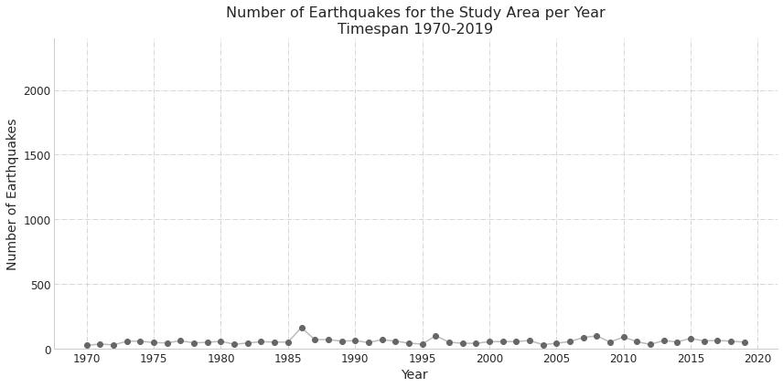

```python
# set the style to a more scientific look
plt.style.use('seaborn-whitegrid')

# set up the matplotlib figure
fig, ax = plt.subplots(figsize=(12, 6))

# aggregating the data by 'year' (or preparing data to create a lineplot)
data = earthquakes_enriched.groupby('year').size().reset_index(name='count')

# plot the lineplot with dots
sns.lineplot(data=data, x='year', y='count', ax=ax, color='#bbbbbb', label='')
ax.plot(data['year'], data['count'], 'o', color='#666666', label='Number of Earthquakes')

# set y-axis limits
ax.set_ylim(0, 2400)

# set x-axis ticks for every 5 years
ax.set_xticks(np.arange(1970, 2021, 5))

# set labels font size
ax.tick_params(axis='x', labelsize=12)
ax.tick_params(axis='y', labelsize=12)

# Enable dashed grid on x-axis for these ticks
ax.grid(linestyle='-.')

# customize the plot
ax.set_xlabel('Year', fontsize=14)
ax.set_ylabel('Number of Earthquakes', fontsize=14)
ax.set_title('Number of Earthquakes for the Study Area per Year\nTimespan 1970-2019', fontsize=16)

# remove top and right spines
ax.spines['top'].set_visible(False)
ax.spines['right'].set_visible(False)

# adjust layout
plt.tight_layout()

# show the figure
plt.show()
```